# Case Study: Brain Cancer Prediction

by: Shaiva Muthaiyah ID: AA.SC.P2MCA2301014

### Objective

The primary objective of this case study is to delve into the intricate relationship between various genes, their expression levels, and their role in the development of cancer. To provide a clear and accessible overview of the data, we present a simple example that elucidates the meaning of these values and their corresponding functions.

### Examples of Genes and their functions:

Consider the following table, which offers a concise insight into the nature of the data and the functions associated with the provided values:

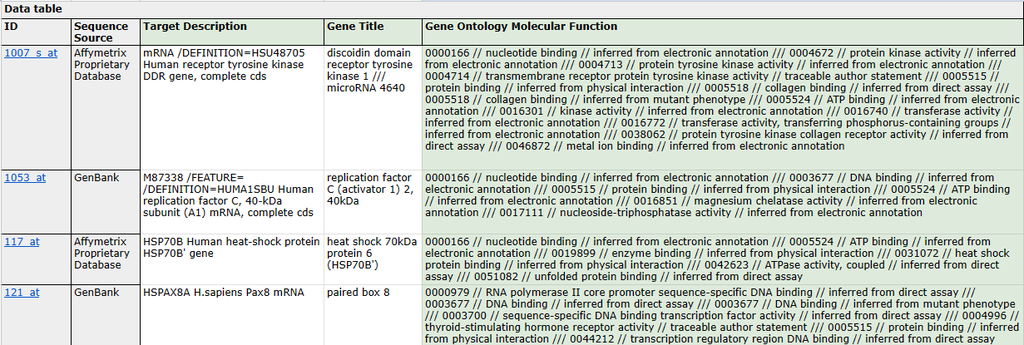

### Brief description of the cancers covered:

### Glioblastoma:

Glioblastoma is an aggressive and fast-growing type of glioma, which arises from the glial cells in the brain. It is the most common and malignant form of glioma. Glioblastomas are known for their infiltrative nature, making complete surgical removal challenging. They tend to recur despite aggressive treatment. Prognosis for glioblastoma is often poor due to its aggressive behavior and resistance to standard treatments.

### Astrocytoma:

Astrocytomas are tumors that originate from astrocytes, a type of glial cell. They can range from low-grade (slow-growing) to high-grade (more aggressive) forms. Low-grade astrocytomas may progress to higher grades over time. High-grade astrocytomas, like glioblastoma, can be challenging to treat effectively. Prognosis varies based on the grade of the tumor, with higher-grade astrocytomas generally having a more guarded prognosis.

### Oligodendroglioma:

Oligodendrogliomas arise from oligodendrocytes, another type of glial cell. They are characterized by a more well-defined border compared to other gliomas. Oligodendrogliomas can be slow-growing and are often associated with a more favorable prognosis compared to some other gliomas. Prognosis depends on factors such as the tumor grade, location, and the effectiveness of treatment. Higher-grade oligodendrogliomas may require more aggressive management.

### Glioblastoma Cell Line:

Glioblastoma cell lines are cultured cells derived from glioblastoma tumors. These cell lines are commonly used in laboratory research to study the biology of glioblastomas and test potential treatments. Glioblastoma cell lines provide a controlled environment for researchers to investigate the molecular and cellular mechanisms underlying glioblastoma development and progression. Research using glioblastoma cell lines contributes to the development of novel therapies and a deeper understanding of the disease at the cellular level.

### Gene Expression Level Explanation:

The numerical value associated with gene expression level typically represents the quantity or abundance of messenger RNA (mRNA) for a specific gene in a given sample. Some details are listed below:

- Continuous Scale: Values are often reported on a continuous scale. The specific unit depends on the technology used (e.g., log-transformed intensities in microarrays or normalized counts in RNA sequencing).
- Magnitude of Expression: Higher values generally represent a higher abundance of mRNA for the corresponding gene in the given sample.